# Correction des exercices

Benoît Simon-Bouhet

Vendredi 29 octobre 2021

# Chapitre 2

## Exercice 2.4

Installation et chargement de `ggplot2` :

```r
# Installation du package ggplot2
# install.packages(ggplot2)

# Mise en mémoire du package
library(ggplot2)
```

Mise en mémoire du jeu de données `diamonds` :

```r
# Chargement du jeu de données diamonds
data(diamonds)
```

Détermination du nombre de lignes de ce tableau :

```r
# Nombre de lignes de diamonds
diamonds
```

| carat | cut | color | clarity | depth | table | price | x | y | z |
| --- | --- | --- | --- | --- | --- | --- | --- | --- | --- |
| 0.23 | Ideal | E | SI2 | 61.5 | 55.0 | 326 | 3.95 | 3.98 | 2.43 |
| 0.21 | Premium | E | SI1 | 59.8 | 61.0 | 326 | 3.89 | 3.84 | 2.31 |
| 0.23 | Good | E | VS1 | 56.9 | 65.0 | 327 | 4.05 | 4.07 | 2.31 |
| 0.29 | Premium | I | VS2 | 62.4 | 58.0 | 334 | 4.20 | 4.23 | 2.63 |
| 0.31 | Good | J | SI2 | 63.3 | 58.0 | 335 | 4.34 | 4.35 | 2.75 |
| 0.24 | Very Good | J | VVS2 | 62.8 | 57.0 | 336 | 3.94 | 3.96 | 2.48 |
| 0.24 | Very Good | I | VVS1 | 62.3 | 57.0 | 336 | 3.95 | 3.98 | 2.47 |
| 0.26 | Very Good | H | SI1 | 61.9 | 55.0 | 337 | 4.07 | 4.11 | 2.53 |
| 0.22 | Fair | E | VS2 | 65.1 | 61.0 | 337 | 3.87 | 3.78 | 2.49 |
| 0.23 | Very Good | H | VS1 | 59.4 | 61.0 | 338 | 4.00 | 4.05 | 2.39 |

[output cut: 990 more lines]

```r
nrow(diamonds)
```

```
[1] 53940
```

```r
str(diamonds)
```

```
tibble [53,940 × 10] (S3: tbl_df/tbl/data.frame)
 $ carat  : num [1:53940] 0.23 0.21 0.23 0.29 0.31 0.24 0.24 0.26 0.22 0.23 ...
 $ cut    : Ord.factor w/ 5 levels "Fair"<"Good"<..: 5 4 2 4 2 3 3 3 1 3 ...
 $ color  : Ord.factor w/ 7 levels "D"<"E"<"F"<"G"<..: 2 2 2 6 7 7 6 5 2 5 ...
 $ clarity: Ord.factor w/ 8 levels "I1"<"SI2"<"SI1"<..: 2 3 5 4 2 6 7 3 4 5 ...
 $ depth  : num [1:53940] 61.5 59.8 56.9 62.4 63.3 62.8 62.3 61.9 65.1 59.4 ...
 $ table  : num [1:53940] 55 61 65 58 58 57 57 55 61 61 ...
 $ price  : int [1:53940] 326 326 327 334 335 336 336 337 337 338 ...
 $ x      : num [1:53940] 3.95 3.89 4.05 4.2 4.34 3.94 3.95 4.07 3.87 4 ...
 $ y      : num [1:53940] 3.98 3.84 4.07 4.23 4.35 3.96 3.98 4.11 3.78 4.05 ...
 $ z      : num [1:53940] 2.43 2.31 2.31 2.63 2.75 2.48 2.47 2.53 2.49 2.39 ...
```

Création de `diamants_chers` contenant uniquement les infos des diamants de plus de 15000 USD :

```r
# Première méthode :
diamants_chers <- diamonds[diamonds$price > 15000, ]

# Deuxième méthode :
diamants_chers <- subset(diamonds, diamonds$price > 15000)

# Troisième méthode
library(dplyr)
diamants_chers <- diamonds %>%
  filter(price > 15000)

diamants_chers
```

| carat | cut | color | clarity | depth | table | price | x | y | z |
| --- | --- | --- | --- | --- | --- | --- | --- | --- | --- |
| 1.54 | Premium | E | VS2 | 62.3 | 58.0 | 15002 | 7.31 | 7.39 | 4.58 |
| 1.19 | Ideal | F | VVS1 | 61.5 | 55.0 | 15005 | 6.82 | 6.84 | 4.20 |
| 2.10 | Premium | I | SI1 | 61.5 | 57.0 | 15007 | 8.25 | 8.21 | 5.06 |
| 1.69 | Ideal | D | SI1 | 60.8 | 57.0 | 15011 | 7.69 | 7.71 | 4.68 |
| 1.50 | Very Good | G | VVS2 | 62.9 | 56.0 | 15013 | 7.22 | 7.32 | 4.57 |
| 1.73 | Very Good | G | VS1 | 62.8 | 57.0 | 15014 | 7.57 | 7.72 | 4.80 |
| 2.02 | Premium | G | SI2 | 63.0 | 59.0 | 15014 | 8.05 | 7.95 | 5.03 |
| 2.05 | Very Good | F | SI2 | 61.9 | 56.0 | 15017 | 8.13 | 8.18 | 5.05 |
| 1.50 | Very Good | F | VS1 | 61.6 | 58.0 | 15022 | 7.35 | 7.43 | 4.55 |
| 1.82 | Very Good | G | SI1 | 62.7 | 58.0 | 15025 | 7.68 | 7.75 | 4.84 |

[output cut: 990 more lines]

Nombre de diamants dont le prix dépasse 15000 USD :

```r
sum(diamonds$price > 15000)
```

```
[1] 1655
```

Proportion de diamants dont le prix dépasse 15000 USD

```r
mean(diamonds$price > 15000)
```

```
[1] 0.03068224
```

Tri du tableau par ordre de prix décroissants

```r
## Première méthode
diamants_chers_tri <- diamants_chers[order(diamants_chers$price, decreasing = TRUE), ]

## Seconde méthode
diamants_chers_tri <- diamants_chers %>%
  arrange(desc(price))
```

Affichage des 20 diamants les plus chers

```r
head(diamants_chers_tri, n = 20)
```

| carat | cut | color | clarity | depth | table | price | x | y | z |
| --- | --- | --- | --- | --- | --- | --- | --- | --- | --- |
| 2.29 | Premium | I | VS2 | 60.8 | 60 | 18823 | 8.50 | 8.47 | 5.16 |
| 2.00 | Very Good | G | SI1 | 63.5 | 56 | 18818 | 7.90 | 7.97 | 5.04 |
| 1.51 | Ideal | G | IF | 61.7 | 55 | 18806 | 7.37 | 7.41 | 4.56 |
| 2.07 | Ideal | G | SI2 | 62.5 | 55 | 18804 | 8.20 | 8.13 | 5.11 |
| 2.00 | Very Good | H | SI1 | 62.8 | 57 | 18803 | 7.95 | 8.00 | 5.01 |
| 2.29 | Premium | I | SI1 | 61.8 | 59 | 18797 | 8.52 | 8.45 | 5.24 |
| 2.04 | Premium | H | SI1 | 58.1 | 60 | 18795 | 8.37 | 8.28 | 4.84 |
| 2.00 | Premium | I | VS1 | 60.8 | 59 | 18795 | 8.13 | 8.02 | 4.91 |
| 1.71 | Premium | F | VS2 | 62.3 | 59 | 18791 | 7.57 | 7.53 | 4.70 |
| 2.15 | Ideal | G | SI2 | 62.6 | 54 | 18791 | 8.29 | 8.35 | 5.21 |

[output cut: 10 more lines]

```r
# Une autre façon de faire tout ça avec le pipe et les fonctions de dplyr
library(dplyr)
diamonds %>%
  filter(price >= 15000) %>%
  arrange(desc(price)) %>%
  print(n = 20)
```

| carat | cut | color | clarity | depth | table | price | x | y | z |
| --- | --- | --- | --- | --- | --- | --- | --- | --- | --- |
| 2.29 | Premium | I | VS2 | 60.8 | 60.0 | 18823 | 8.50 | 8.47 | 5.16 |
| 2.00 | Very Good | G | SI1 | 63.5 | 56.0 | 18818 | 7.90 | 7.97 | 5.04 |
| 1.51 | Ideal | G | IF | 61.7 | 55.0 | 18806 | 7.37 | 7.41 | 4.56 |
| 2.07 | Ideal | G | SI2 | 62.5 | 55.0 | 18804 | 8.20 | 8.13 | 5.11 |
| 2.00 | Very Good | H | SI1 | 62.8 | 57.0 | 18803 | 7.95 | 8.00 | 5.01 |
| 2.29 | Premium | I | SI1 | 61.8 | 59.0 | 18797 | 8.52 | 8.45 | 5.24 |
| 2.04 | Premium | H | SI1 | 58.1 | 60.0 | 18795 | 8.37 | 8.28 | 4.84 |
| 2.00 | Premium | I | VS1 | 60.8 | 59.0 | 18795 | 8.13 | 8.02 | 4.91 |
| 1.71 | Premium | F | VS2 | 62.3 | 59.0 | 18791 | 7.57 | 7.53 | 4.70 |
| 2.15 | Ideal | G | SI2 | 62.6 | 54.0 | 18791 | 8.29 | 8.35 | 5.21 |

[output cut: 990 more lines]

# Chapitre 3

```r
# Mise en mémoire des packages utiles
library(dplyr)
library(nycflights13)
```

```r
# Affichage du tableau flights dans un onglet de RStudio
View(flights)
```

## Exercices 3.3.1

- Chacune des lignes du tableau corrspond aux données d’un vol (réponse B)
- Nombre de vols ayant décollé de JFK le 12 février 2013 : 282. On le détermine en ajustant les sliders, les filtres, etc.

## Exercices 3.3.2

Les variables catégorielles sont :

1. `tailnum` (numéro d’identification de l’avion),
2. `origin` (aéroport de départ de l’avion),
3. `dest` (aéroport de destination de l’avion),
4. `carrier` (compagnie aérienne)

Les valeurs sont des chaînes de caractères et non des chiffres.

## Exercices 3.4

Consultez l’aide du jeu de données diamonds du package ggplot2.

```r
library(ggplot2)
?diamonds
```

- Quel est le code de la couleur la plus prisée ? `D`
- Quel est le code de la moins bonne clarté ? `I1`
- À quoi correspond la variable `z` ? La profondeur des diamands en millimètres
- En quoi la variable `depth` est-elle différente de la variable `z` ? Il s’agit d’un ratio entre z et la moyenne des 2 autres dimensions du diamands

Consultez l’aide du package nycflights13 en tapant help(package=“nycflights13”).

```r
help(package="nycflights13")
```

Consultez l’aide des 5 jeux de données de ce package.

```r
?airlines
?airports
?flights
?planes
?weather
```

- À quoi correspond la variable `visib` ? Visibilité en miles
- Dans quel tableau se trouve-t’elle ? `weather`
- Combien de lignes possède ce tableau ?

```r
# Nombre de lignes du tableau weather
nrow(weather)
```

```
[1] 26115
```

# Chapitre 4

```r
library(tidyverse)
library(nycflights13)
```

## Exercices 4.3

`alaska_flights` contient les mêmes variables que flights, mais beaucoup moins de lignes : seulement 714.

```r
alaska_flights <- flights %>%
  filter(carrier == "AS")

alaska_flights
```

| year | month | day | dep_time | sched_dep_time | dep_delay | arr_time | sched_arr_time | arr_delay | carrier | flight | tailnum | origin | dest | air_time | distance | hour | minute | time_hour |
| --- | --- | --- | --- | --- | --- | --- | --- | --- | --- | --- | --- | --- | --- | --- | --- | --- | --- | --- |
| 2013 | 1 | 1 | 724 | 725 | -1 | 1020 | 1030 | -10 | AS | 11 | N594AS | EWR | SEA | 338 | 2402 | 7 | 25 | 2013-01-01 07:00:00 |
| 2013 | 1 | 1 | 1808 | 1815 | -7 | 2111 | 2130 | -19 | AS | 7 | N553AS | EWR | SEA | 336 | 2402 | 18 | 15 | 2013-01-01 18:00:00 |
| 2013 | 1 | 2 | 722 | 725 | -3 | 949 | 1030 | -41 | AS | 11 | N592AS | EWR | SEA | 314 | 2402 | 7 | 25 | 2013-01-02 07:00:00 |
| 2013 | 1 | 2 | 1818 | 1815 | 3 | 2131 | 2130 | 1 | AS | 7 | N552AS | EWR | SEA | 332 | 2402 | 18 | 15 | 2013-01-02 18:00:00 |
| 2013 | 1 | 3 | 724 | 725 | -1 | 1012 | 1030 | -18 | AS | 11 | N533AS | EWR | SEA | 325 | 2402 | 7 | 25 | 2013-01-03 07:00:00 |
| 2013 | 1 | 3 | 1817 | 1815 | 2 | 2121 | 2130 | -9 | AS | 7 | N552AS | EWR | SEA | 327 | 2402 | 18 | 15 | 2013-01-03 18:00:00 |
| 2013 | 1 | 4 | 725 | 725 | 0 | 1031 | 1030 | 1 | AS | 11 | N579AS | EWR | SEA | 345 | 2402 | 7 | 25 | 2013-01-04 07:00:00 |
| 2013 | 1 | 4 | 1808 | 1815 | -7 | 2101 | 2130 | -29 | AS | 7 | N553AS | EWR | SEA | 338 | 2402 | 18 | 15 | 2013-01-04 18:00:00 |
| 2013 | 1 | 5 | 725 | 725 | 0 | 1011 | 1030 | -19 | AS | 11 | N546AS | EWR | SEA | 330 | 2402 | 7 | 25 | 2013-01-05 07:00:00 |
| 2013 | 1 | 5 | 1803 | 1815 | -12 | 2118 | 2130 | -12 | AS | 7 | N558AS | EWR | SEA | 343 | 2402 | 18 | 15 | 2013-01-05 18:00:00 |

[output cut: 704 more lines]

## Exercices 4.3.3

*1. Donnez une raison pratique expliquant pourquoi les variables `dep_delay` et `arr_delay` ont une relation positive.*

Le retard au départ se répercute forcément sur le retard à l’arrivée. Sauf s’il est possible pour un avion de rattraper son retard en vol, ce qui semble peu probable.

*2. Quelles variables (pas nécessairement dans le tableau `alaska_flights`) pourraient avoir une corrélation négative (relation négative) avec `dep_delay` ? Pourquoi ? Rappelez-vous que nous étudions ici des variables numériques.*

On peut supposer que la température, la visibilité et le rayonnement solaire sont corrélés négativement à `dep_delay`. Quand les conditions météos se dégradent (moins de soleil, température plus faible, plus de brouillard donc moins de visibilité) les retards augmentent car les avions et les pistes doivent être (re)mis en état plus souvent. Cela demande plus de maintenance.

*3. Selon vous, pourquoi tant de points sont-il regroupés près de (0, 0) ?*

La majorité des vols décollent et aterrisent à l’heure ou avec peu d’avance ou de retard

*4. À quoi le point (0,0) correspond-il pour les vols d’Alaska Airlines ?*

Cela correspond à la situation idéale de décollage et d’aterrissage à l’heure.

*5. Citez les éléments de ce graphique/de ces données qui vous sautent le plus aux yeux ?*

Il s’agit ici de réaliser l’exercice qui est demandé dans la partie “résultats” de tout rapport ou compte rendu. Ici, il y a 4 choses à décrire :

1. La relation entre les 2 variables est positive.
2. La relation entre les 2 variables semble linéaire.
3. La grande majorité des vols est à peu près à l’heure, dans une fourchette de 25 minutes d’avance ou de retard, au départ comme à l’arrivée.
4. Il y a toutefois une forte variabilité avec des valeurs extrêmes très fortes : certains vols accumulent plus de 3h de retard.

On discute donc de la nature de la relation, de sa forme, de la tendance centrale (où sont situés la majorité des points) et des extrêmes.

*6. Créez un nouveau nuage de points en utilisant d’autres variables du jeu de données `alaska_flights`*

Pour tenter de vérifier notre hypothèse sur le lien entre météo et retard :

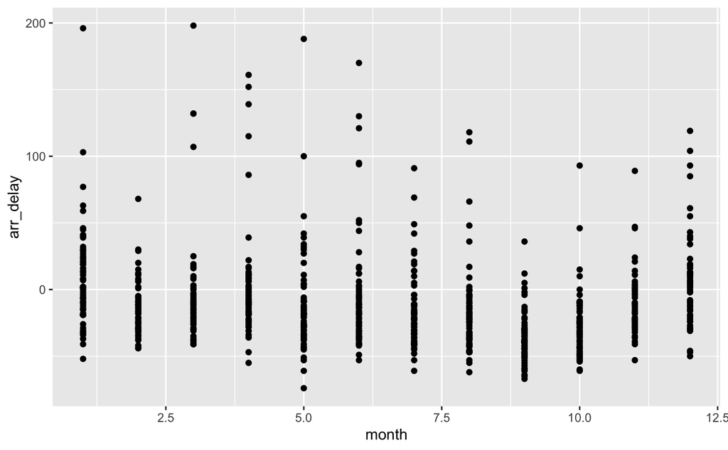

```r
ggplot(data = alaska_flights, aes(x = month, y = arr_delay)) +
  geom_point()
```

## Exercices 4.3.6

L’argument `stroke` permet de spécifier l’épaisseur des traits utilisés pour tracer les symboles (cercles, carrés, etc.) sur un graphique.

Création du jeu de données `diams` :

```r
set.seed(4532) # Afin que tout le monde récupère les mêmes lignes
diams <- diamonds %>%
  sample_n(5000)
```

Création du graphique :

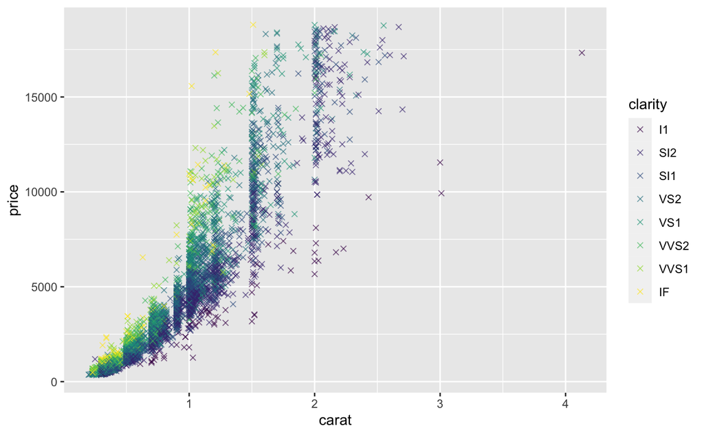

```r
ggplot(diams, aes(x = carat, y = price, color = clarity)) +
  geom_point(shape = 4, alpha = 0.6)
```

Revenir sur la position des arguments esthétiques : dans `ggplot()` ou dans `geom_XXX()` ?

- À quoi sont dues les bandes verticales ?*

Les bandes verticales sont le résultat d’approximations humaines. On a tendance à arrondir au carat “rond” immédiatement supérieur (2 au lieu de 1.98, 1.7 au lieu de 1.69, etc), car la valeur marchande dépend du carat.

## Exercices 4.4.2

Création du jeu de données `small_weather` :

```r
small_weather <- weather %>%
  filter(origin == "EWR",
         month == 1,
         day <= 15)

small_weather
```

| origin | year | month | day | hour | temp | dewp | humid | wind_dir | wind_speed | wind_gust | precip | pressure | visib | time_hour |
| --- | --- | --- | --- | --- | --- | --- | --- | --- | --- | --- | --- | --- | --- | --- |
| EWR | 2013 | 1 | 1 | 1 | 39.02 | 26.06 | 59.37 | 270 | 10.35702 | NA | 0.00 | 1012.0 | 10.00 | 2013-01-01 01:00:00 |
| EWR | 2013 | 1 | 1 | 2 | 39.02 | 26.96 | 61.63 | 250 | 8.05546 | NA | 0.00 | 1012.3 | 10.00 | 2013-01-01 02:00:00 |
| EWR | 2013 | 1 | 1 | 3 | 39.02 | 28.04 | 64.43 | 240 | 11.50780 | NA | 0.00 | 1012.5 | 10.00 | 2013-01-01 03:00:00 |
| EWR | 2013 | 1 | 1 | 4 | 39.92 | 28.04 | 62.21 | 250 | 12.65858 | NA | 0.00 | 1012.2 | 10.00 | 2013-01-01 04:00:00 |
| EWR | 2013 | 1 | 1 | 5 | 39.02 | 28.04 | 64.43 | 260 | 12.65858 | NA | 0.00 | 1011.9 | 10.00 | 2013-01-01 05:00:00 |
| EWR | 2013 | 1 | 1 | 6 | 37.94 | 28.04 | 67.21 | 240 | 11.50780 | NA | 0.00 | 1012.4 | 10.00 | 2013-01-01 06:00:00 |
| EWR | 2013 | 1 | 1 | 7 | 39.02 | 28.04 | 64.43 | 240 | 14.96014 | NA | 0.00 | 1012.2 | 10.00 | 2013-01-01 07:00:00 |
| EWR | 2013 | 1 | 1 | 8 | 39.92 | 28.04 | 62.21 | 250 | 10.35702 | NA | 0.00 | 1012.2 | 10.00 | 2013-01-01 08:00:00 |
| EWR | 2013 | 1 | 1 | 9 | 39.92 | 28.04 | 62.21 | 260 | 14.96014 | NA | 0.00 | 1012.7 | 10.00 | 2013-01-01 09:00:00 |
| EWR | 2013 | 1 | 1 | 10 | 41.00 | 28.04 | 59.65 | 260 | 13.80936 | NA | 0.00 | 1012.4 | 10.00 | 2013-01-01 10:00:00 |

[output cut: 348 more lines]

*Expliquez pourquoi la variable `time_hour` identifie de manière unique le moment ou chaque mesure a été réalisée alors que ce n’est pas le cas de la variable `hour`.*

`hour` est une variable entière qui prend les valeurs 0 à 23 chaque jour de l’année. Indiquer qu’une mesure a été faite à 13h n’est pas suffisant car elle a pu être faite n’importe que jour. La variable `time-hour` contient la date et l’heure de chaque mesure, ce qui en fait un identifiant unique de chaque mesure.

## Exercices 4.6.3

*Examinez la figure 4.37.*

*1. Quels éléments nouveaux ce graphiques nous apprend-il par rapport au graphique 4.34 ci-dessus ? Comment le “faceting” nous aide-t’il à visualiser les relations entre 2 (ou 3) variables ?*

La nature bimodale de la distribution de la première figure cache en fait une distribution mensuelle des températures unimodale tout à fait classique, et ce, pour les 3 aéroports. Ce graphique nous permet également de visualiser la variabilité mensuelle, annuelle, et entre les aéroports ce qui était impossible avec l’histogramme synthétique de la figure 4.34.

- Les comparaisons en ligne nous permettent de comparer les température pour un mois donné entre les 3 aéroports. Nous constatons ici que ces températures sont toujours très similaires. Les distributions des températures dans les 3 aéroports de NY sont très proches. Ce qui est finalement tout à fait normal compte tenu de leur proximité géographique.
- Les comparaisons en colonnes nous permettent de visualiser l’évolution mensuelle des températures pour un aéroport donné. Ici, on constate que l’amplitude varie, de même que la position des pics : il fait plus chaud l’été que l’hiver. Là encore, c’est logique, nous sommes dans l’hémisphère Nord.

*2. À quoi correspondent les numéros 1 à 12 ?*

Aux mois de l’année

*3. À quoi correspondent les chiffres 25, 50, 75, 100 ?*

Aux températures en degrés farenheit

*4. À quoi correspondent les chiffres 0, 100, 200, 300 ?*

Au nombre d’observations pour chaque catégorie

*5. Observez les échelles des axes `x` et `y` pour chaque sous graphique. Qu’on-t’elles de particulier ? En quoi est-ce utile ?*

Elles sont toutes identiques. Elles facilitent ainsi les comparaisons entre sous-graphiques. Nous verrons peut-être plus tard que ce n’est pas toujours souhaitable.

*6. La variabilité des températures est-elle plus importante entre les aéroports, entre les mois, ou au sein des mois ? Expliquez votre réflexion.*

La variabilité des températures entre aéroports est très faible : pour un mois donné, les températures observées sont distribuées de façon très similaire dans les 3 aéroports. La variabilité entre les mois est plus importante : au sein d’un mois, la distribution des températures couvre rarement plus de 30º Farenheit alors qu’elle atteint presque 50º Farenheit entre les mois d’été et les mois d’hiver.

## Exercice 4.8.3

*1. Quelle est la différence entre un histogramme et un diagramme bâtons ?*

- Un histogramme permet de visualiser la distribution d’une variable continue.
- Un diagramme bâtons permet de visualiser la distribution d’une variable catégorielle

*2. Pourquoi les histogrammes sont-ils inadaptés pour visualiser des données catégorielles ?*

Parce que les barres sont collées les unes aux autres ce qui donne une impression visuelle de continuité. Par ailleurs, les barres ne peuvent pas être ré-ordonnées, ce qui est souvent nécessaire pour une variable catégorielle.

*3. Quel est le nom de la companie pour laquelle le plus grand nombre de vols ont quitté New York en 2013 (je veux connaître son nom, pas juste son code) ? Où se trouve cette information ?*

On examine la figure 4.47 (par exemple) et on constate que la compagnie en question a le code `UA`. Le nom complet de cette compagnie se trouve dans le tableau `airlines`. Ce tableau fait le lien entre codes et nom des compagnies aériennes.

La compagnie qui a affrété le plus grand nombre de vols au départ de New York en 2013 est United Air Lines Inc.

```r
airlines
```

| carrier | name |
| --- | --- |
| 9E | Endeavor Air Inc. |
| AA | American Airlines Inc. |
| AS | Alaska Airlines Inc. |
| B6 | JetBlue Airways |
| DL | Delta Air Lines Inc. |
| EV | ExpressJet Airlines Inc. |
| F9 | Frontier Airlines Inc. |
| FL | AirTran Airways Corporation |
| HA | Hawaiian Airlines Inc. |
| MQ | Envoy Air |

[output cut: 6 more lines]

*4. Quel est le nom de la companie pour laquelle le plus petit nombre de vols ont quitté New York en 2013 (je veux connaître son nom, pas juste son code) ? Où se trouve cette information ?*

Même démarche : il s’agit de la compagnie Skywest Airlines Inc. (code `OO`).

## Exercices 4.8.4

La figure 4.47 et la tableau `carrier_table` permettent de répondre aux questions suivantes

*Comparez les compagnies ExpressJet Airlines (EV) et US Airways (US). De combien de fois la part de EV est-elle supérieure à celle d’US ? (2 fois, 3 fois, 1.2 fois ?…)*

Un peu plus de 2,5

*Quelle est la troisième compagnie aérienne la plus importante en terme de nombre de vols au départ de New York en 2013 ?*

ExpressJet Airlines (`EV`)

*Combien de companies aériennes ont moins de vols que United Airlines (`UA`) ?*

Toutes, soit 15 au total

## Exercices 4.10

Création du jeu de données :

```r
# On fixe le générateur de nombres aléatoires pour choisir les mêmes lignes que dans l'exemple du livre
set.seed(1234)

# Création de small_flights
small_flights <- flights %>%
  sample_n(1000) %>%
  filter(!is.na(arr_delay),
         distance < 3000)

small_flights
```

| year | month | day | dep_time | sched_dep_time | dep_delay | arr_time | sched_arr_time | arr_delay | carrier | flight | tailnum | origin | dest | air_time | distance | hour | minute | time_hour |
| --- | --- | --- | --- | --- | --- | --- | --- | --- | --- | --- | --- | --- | --- | --- | --- | --- | --- | --- |
| 2013 | 6 | 17 | 1033 | 1040 | -7 | 1246 | 1309 | -23 | UA | 244 | N447UA | EWR | LAS | 290 | 2227 | 10 | 40 | 2013-06-17 10:00:00 |
| 2013 | 12 | 26 | 1343 | 1329 | 14 | 1658 | 1624 | 34 | DL | 2455 | N373NW | LGA | MCO | 145 | 950 | 13 | 29 | 2013-12-26 13:00:00 |
| 2013 | 8 | 26 | 1258 | 1218 | 40 | 1510 | 1516 | -6 | UA | 1623 | N38727 | EWR | SNA | 290 | 2434 | 12 | 18 | 2013-08-26 12:00:00 |
| 2013 | 8 | 17 | 1558 | 1600 | -2 | 1835 | 1849 | -14 | B6 | 543 | N558JB | EWR | PBI | 139 | 1023 | 16 | 0 | 2013-08-17 16:00:00 |
| 2013 | 6 | 30 | 905 | 900 | 5 | 1200 | 1206 | -6 | B6 | 5 | N807JB | EWR | FLL | 152 | 1065 | 9 | 0 | 2013-06-30 09:00:00 |
| 2013 | 9 | 15 | 1017 | 1025 | -8 | 1245 | 1325 | -40 | AA | 1131 | N3KMAA | LGA | DFW | 185 | 1389 | 10 | 25 | 2013-09-15 10:00:00 |
| 2013 | 5 | 7 | 1623 | 1627 | -4 | 1819 | 1818 | 1 | EV | 4411 | N14558 | EWR | MEM | 130 | 946 | 16 | 27 | 2013-05-07 16:00:00 |
| 2013 | 3 | 14 | 703 | 645 | 18 | 854 | 846 | 8 | US | 1281 | N169UW | EWR | CLT | 81 | 529 | 6 | 45 | 2013-03-14 06:00:00 |
| 2013 | 9 | 4 | 739 | 740 | -1 | 1030 | 1055 | -25 | VX | 11 | N846VA | JFK | SFO | 333 | 2586 | 7 | 40 | 2013-09-04 07:00:00 |
| 2013 | 7 | 31 | 853 | 853 | 0 | 1209 | 1212 | -3 | B6 | 15 | N536JB | JFK | SFO | 348 | 2586 | 8 | 53 | 2013-07-31 08:00:00 |

[output cut: 959 more lines]

Création du premier graphique

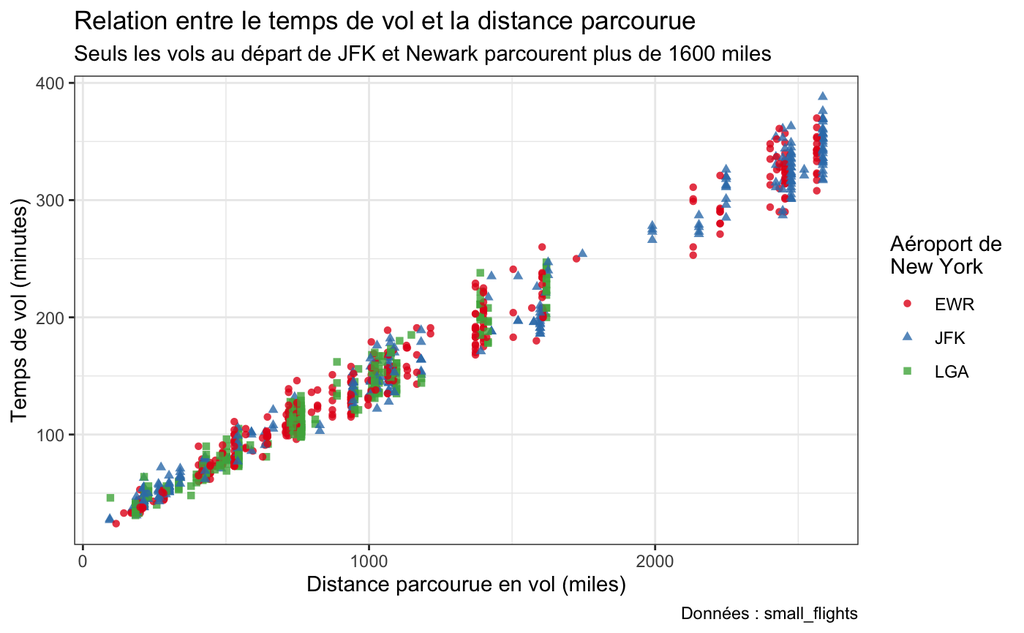

```r
ggplot(small_flights, aes(x = distance,
                          y = air_time,
                          color = origin,
                          shape = origin)) +
  geom_point(alpha = 0.8) +
  scale_color_brewer(palette = "Set1") +
  labs(x = "Distance parcourue en vol (miles)",
       y = "Temps de vol (minutes)",
       title = "Relation entre le temps de vol et la distance parcourue",
       subtitle = "Seuls les vols au départ de JFK et Newark parcourent plus de 1600 miles",
       color = "Aéroport de\nNew York",
       shape = "Aéroport de\nNew York",
       caption = "Données : small_flights") +
  theme_bw()
```

Création du second graphique

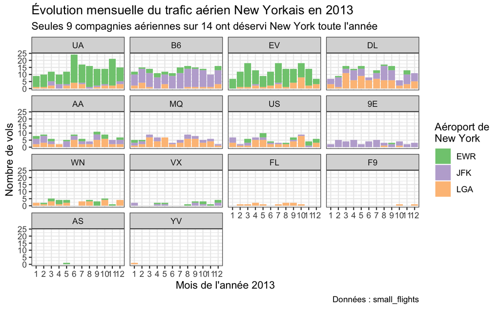

```r
ggplot(small_flights, aes(x = factor(month), fill = origin)) +
  geom_bar() +
  facet_wrap(~ fct_infreq(carrier), nrow = 4) +
  scale_fill_brewer(palette = "Accent") +
  labs(x = "Mois de l'année 2013",
       y = "Nombre de vols",
       title = "Évolution mensuelle du trafic aérien New Yorkais en 2013",
       subtitle = "Seules 9 compagnies aériennes sur 14 ont déservi New York toute l'année",
       fill = "Aéroport de\nNew York",
       caption = "Données : small_flights") +
  theme_bw()
```

```r
small_flights
```

| year | month | day | dep_time | sched_dep_time | dep_delay | arr_time | sched_arr_time | arr_delay | carrier | flight | tailnum | origin | dest | air_time | distance | hour | minute | time_hour |
| --- | --- | --- | --- | --- | --- | --- | --- | --- | --- | --- | --- | --- | --- | --- | --- | --- | --- | --- |
| 2013 | 6 | 17 | 1033 | 1040 | -7 | 1246 | 1309 | -23 | UA | 244 | N447UA | EWR | LAS | 290 | 2227 | 10 | 40 | 2013-06-17 10:00:00 |
| 2013 | 12 | 26 | 1343 | 1329 | 14 | 1658 | 1624 | 34 | DL | 2455 | N373NW | LGA | MCO | 145 | 950 | 13 | 29 | 2013-12-26 13:00:00 |
| 2013 | 8 | 26 | 1258 | 1218 | 40 | 1510 | 1516 | -6 | UA | 1623 | N38727 | EWR | SNA | 290 | 2434 | 12 | 18 | 2013-08-26 12:00:00 |
| 2013 | 8 | 17 | 1558 | 1600 | -2 | 1835 | 1849 | -14 | B6 | 543 | N558JB | EWR | PBI | 139 | 1023 | 16 | 0 | 2013-08-17 16:00:00 |
| 2013 | 6 | 30 | 905 | 900 | 5 | 1200 | 1206 | -6 | B6 | 5 | N807JB | EWR | FLL | 152 | 1065 | 9 | 0 | 2013-06-30 09:00:00 |
| 2013 | 9 | 15 | 1017 | 1025 | -8 | 1245 | 1325 | -40 | AA | 1131 | N3KMAA | LGA | DFW | 185 | 1389 | 10 | 25 | 2013-09-15 10:00:00 |
| 2013 | 5 | 7 | 1623 | 1627 | -4 | 1819 | 1818 | 1 | EV | 4411 | N14558 | EWR | MEM | 130 | 946 | 16 | 27 | 2013-05-07 16:00:00 |
| 2013 | 3 | 14 | 703 | 645 | 18 | 854 | 846 | 8 | US | 1281 | N169UW | EWR | CLT | 81 | 529 | 6 | 45 | 2013-03-14 06:00:00 |
| 2013 | 9 | 4 | 739 | 740 | -1 | 1030 | 1055 | -25 | VX | 11 | N846VA | JFK | SFO | 333 | 2586 | 7 | 40 | 2013-09-04 07:00:00 |
| 2013 | 7 | 31 | 853 | 853 | 0 | 1209 | 1212 | -3 | B6 | 15 | N536JB | JFK | SFO | 348 | 2586 | 8 | 53 | 2013-07-31 08:00:00 |

[output cut: 959 more lines]

# Chapitre 5

## Exercice 5.2.4

*Examinez les tableaux rates, storms et population du package EDAWR.*

- Ces tableaux sont-ils des “tableaux rangés” (tidy data) ?
- Si oui, quelles sont les variables représentées ?
- Si non, transformez-les en “tableaux rangés”.

```r
# Installation et mise en mémoire des packages nécessaires
library(tidyverse)

# install.packages("devtools")
# library(devtools)

# install_github("rstudio/EDAWR")
library(EDAWR)
```

Affichage des tableaux :

```r
rates
```

| country | year | cases | population | rate |
| --- | --- | --- | --- | --- |
| Afghanistan | 1997 | 128 | 19021226 | 0.07 |
| Afghanistan | 1998 | 1778 | 19496836 | 0.91 |
| Afghanistan | 1999 | 745 | 19987071 | 0.37 |
| Afghanistan | 2000 | 2666 | 20595360 | 1.29 |
| Afghanistan | 2001 | 4639 | 21347782 | 2.17 |
| Afghanistan | 2002 | 6509 | 22202806 | 2.93 |
| Afghanistan | 2003 | 6528 | 23116142 | 2.82 |
| Afghanistan | 2004 | 8245 | 24018682 | 3.43 |
| Afghanistan | 2005 | 9949 | 24860855 | 4.00 |
| Afghanistan | 2006 | 12469 | 25631282 | 4.86 |

[output cut: 990 more lines]

`rates` est un tableau rangé avec une variable par colonne (pays, année, nombre de cas de tuberculose, population globale, et taux de malades) et une ligne par observation.

```r
storms
```

| storm | wind | pressure | date |
| --- | --- | --- | --- |
| Alberto | 110 | 1007 | 2000-08-03 |
| Alex | 45 | 1009 | 1998-07-27 |
| Allison | 65 | 1005 | 1995-06-03 |
| Ana | 40 | 1013 | 1997-06-30 |
| Arlene | 50 | 1010 | 1999-06-11 |
| Arthur | 45 | 1010 | 1996-06-17 |

`storms` est un tableau rangé avec une variable par colonne (nom de la tempête, vitesse du vent en mph, pression en millibars et date à laquelle la plus forte vitesse de vent a été enregistrée) et une ligne par observation.

```r
population
```

|  | country | 1995 | 1996 | 1997 | 1998 | 1999 | 2000 | 2001 | 2002 | 2003 | 2004 | 2005 | 2006 | 2007 | 2008 | 2009 | 2010 | 2011 | 2012 | 2013 |
| --- | --- | --- | --- | --- | --- | --- | --- | --- | --- | --- | --- | --- | --- | --- | --- | --- | --- | --- | --- | --- |
| 1 | Afghanistan | 17586073 | 18415307 | 19021226 | 19496836 | 19987071 | 20595360 | 21347782 | 22202806 | 23116142 | 24018682 | 24860855 | 25631282 | 26349243 | 27032197 | 27708187 | 28397812 | 29105480 | 29824536 | 30551674 |
| 2 | Algeria | 29315463 | 29845208 | 30345466 | 30820435 | 31276295 | 31719449 | 32150198 | 32572977 | 33003442 | 33461345 | 33960903 | 34507214 | 35097043 | 35725377 | 36383302 | 37062820 | 37762962 | 38481705 | 39208194 |
| 3 | Angola | 12104952 | 12451945 | 12791388 | 13137542 | 13510616 | 13924930 | 14385283 | 14886574 | 15421075 | 15976715 | 16544376 | 17122409 | 17712824 | 18314441 | 18926650 | 19549124 | 20180490 | 20820525 | 21471618 |
| 4 | Argentina | 34833168 | 35264070 | 35690778 | 36109342 | 36514558 | 36903067 | 37273361 | 37627545 | 37970411 | 38308779 | 38647854 | 38988923 | 39331357 | 39676083 | 40023641 | 40374224 | 40728738 | 41086927 | 41446246 |
| 5 | Azerbaijan | 7770806 | 7852273 | 7921745 | 7984460 | 8047936 | 8117742 | 8195427 | 8279768 | 8370169 | 8465127 | 8563398 | 8665006 | 8770122 | 8877669 | 8986266 | 9094718 | 9202432 | 9308959 | 9413420 |
| 6 | Bangladesh | 119869585 | 122400896 | 124945315 | 127478524 | 129966823 | 132383265 | 134729503 | 137006279 | 139185986 | 141235035 | 143135180 | 144868702 | 146457067 | 147969967 | 149503100 | 151125475 | 152862431 | 154695368 | 156594962 |
| 7 | Belarus | 10189075 | 10156258 | 10120556 | 10080772 | 10034775 | 9981460 | 9920173 | 9852866 | 9784111 | 9719991 | 9664714 | 9620359 | 9585368 | 9555801 | 9525785 | 9491070 | 9450391 | 9405097 | 9356678 |
| 8 | Benin | 5985658 | 6176318 | 6361301 | 6546493 | 6740491 | 6949366 | 7174911 | 7414744 | 7665681 | 7922796 | 8182362 | 8443671 | 8707490 | 8973293 | 9240783 | 9509798 | 9779795 | 10050702 | 10323474 |
| 9 | Bolivia (Plurinational State of) | 7635362 | 7806953 | 7978521 | 8150214 | 8322408 | 8495271 | 8669066 | 8843350 | 9016787 | 9187610 | 9354709 | 9517395 | 9676456 | 9834098 | 9993406 | 10156601 | 10324445 | 10496285 | 10671200 |
| 10 | Botswana | 1583453 | 1620989 | 1657349 | 1692148 | 1724924 | 1755375 | 1783349 | 1808976 | 1832602 | 1854739 | 1875805 | 1895944 | 1915187 | 1933719 | 1951715 | 1969341 | 1986701 | 2003910 | 2021144 |

[output cut: 90 more lines]

`population` n’est pas un tableau rangé. Les variables devraient être pays, année et population

```r
pivot_longer(population, col = `1995`:`2013`, names_to = "year", values_to = "pop")
```

| country | year | pop |
| --- | --- | --- |
| Afghanistan | 1995 | 17586073 |
| Afghanistan | 1996 | 18415307 |
| Afghanistan | 1997 | 19021226 |
| Afghanistan | 1998 | 19496836 |
| Afghanistan | 1999 | 19987071 |
| Afghanistan | 2000 | 20595360 |
| Afghanistan | 2001 | 21347782 |
| Afghanistan | 2002 | 22202806 |
| Afghanistan | 2003 | 23116142 |
| Afghanistan | 2004 | 24018682 |

[output cut: 990 more lines]

## Exercice 5.3.4

*1. L’objet dauphin est-il “tidy” (autrement dit, s’agit-il de “données rangées”) ? Justifiez.*

```r
# Importation du jeu de données `dauphin` :
library(readxl)
dauphin <- read_excel("dauphin.xls", na = "*", skip = 9)
names(dauphin) <- c("ID", "Sexe", "Statut", "Taille", "Age", "Cd", "Cu", "Hg", "Organe")
dauphin
```

| ID | Sexe | Statut | Taille | Age | Cd | Cu | Hg | Organe |
| --- | --- | --- | --- | --- | --- | --- | --- | --- |
| Numéro 1 | f | imm | 315 | 3 | 29.60 | 3.24 | NA | rein |
| Numéro 2 | f | imm | 357 | 4 | 55.10 | 4.42 | NA | rein |
| Numéro 3 | f | pnl | 439 | 34 | 129.30 | 5.01 | 9.02 | rein |
| Numéro 4 | f | imm | 316 | 4 | 71.20 | 4.33 | NA | rein |
| Numéro 5 | f | l | 435 | 26 | 192.00 | 5.15 | NA | rein |
| Numéro 6 | f | pnl | 388 | 6 | NA | 4.12 | 4.53 | rein |
| Numéro 7 | f | mat | 410 | NA | 76.00 | 5.10 | 33.90 | foie |
| Numéro 8 | m | imm | 355 | NA | 74.40 | 4.72 | 13.30 | foie |
| Numéro 9 | m | imm | 222 | NA | 0.09 | 9.50 | 2.89 | foie |
| Numéro 10 | m | imm | 412 | 9 | 85.60 | 5.42 | NA | rein |

[output cut: 83 more lines]

Oui, `dauphin` est “tidy”. Il contient une variable par colonne, une observation par ligne. La variable ID pourrait toutefois être supprimée.

*2. Produisez le graphique ci-dessous*

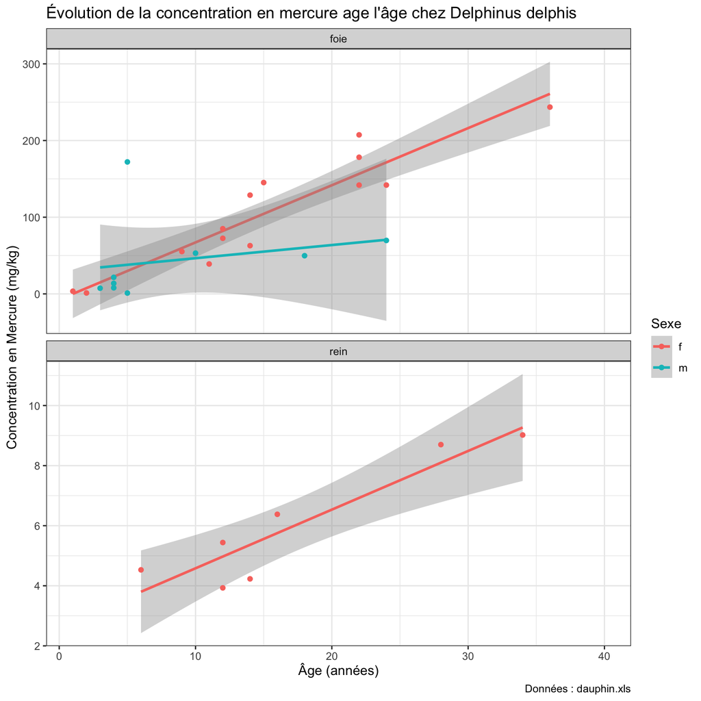

```r
ggplot(dauphin, aes(x = Age, y = Hg, color = Sexe)) +
  geom_smooth(method = "lm") +
  geom_point() +
  facet_wrap(~ Organe, nrow = 2, scales = "free_y") +
  labs(x = "Âge (années)",
       y = "Concentration en Mercure (mg/kg)",
       title = "Évolution de la concentration en mercure age l'âge chez Delphinus delphis",
       color = "Sexe",
       caption = "Données : dauphin.xls") +
  theme_bw()
```

*3. Importez dans R le jeu de données whoTB.csv. Ce jeu de données contient les cas de tuberculose (TB) rapportés par l’Organisation Mondiale de la Santé (OMS, ou WHO en anglais : World Health Organization). Les cas sont répertoriés par année, pays, âge, sexe, type de tuberculose et méthode de diagnostique. Selon vous, ce jeu de données est-il “rangé” ? Pourquoi ?*

```r
library(readr)
whoTB <- read_csv("whoTB.csv")
whoTB
```

| country | iso2 | iso3 | year | new_sp_m014 | new_sp_m1524 | new_sp_m2534 | new_sp_m3544 | new_sp_m4554 | new_sp_m5564 | new_sp_m65 | new_sp_f014 | new_sp_f1524 | new_sp_f2534 | new_sp_f3544 | new_sp_f4554 | new_sp_f5564 | new_sp_f65 | new_sn_m014 | new_sn_m1524 | new_sn_m2534 | new_sn_m3544 | new_sn_m4554 | new_sn_m5564 | new_sn_m65 | new_sn_f014 | new_sn_f1524 | new_sn_f2534 | new_sn_f3544 | new_sn_f4554 | … |
| --- | --- | --- | --- | --- | --- | --- | --- | --- | --- | --- | --- | --- | --- | --- | --- | --- | --- | --- | --- | --- | --- | --- | --- | --- | --- | --- | --- | --- | --- | --- |
| Afghanistan | AF | AFG | 1980 | NA | NA | NA | NA | NA | NA | NA | NA | NA | NA | NA | NA | NA | NA | NA | NA | NA | NA | NA | NA | NA | NA | NA | NA | NA | NA | … |
| Afghanistan | AF | AFG | 1981 | NA | NA | NA | NA | NA | NA | NA | NA | NA | NA | NA | NA | NA | NA | NA | NA | NA | NA | NA | NA | NA | NA | NA | NA | NA | NA | … |
| Afghanistan | AF | AFG | 1982 | NA | NA | NA | NA | NA | NA | NA | NA | NA | NA | NA | NA | NA | NA | NA | NA | NA | NA | NA | NA | NA | NA | NA | NA | NA | NA | … |
| Afghanistan | AF | AFG | 1983 | NA | NA | NA | NA | NA | NA | NA | NA | NA | NA | NA | NA | NA | NA | NA | NA | NA | NA | NA | NA | NA | NA | NA | NA | NA | NA | … |
| Afghanistan | AF | AFG | 1984 | NA | NA | NA | NA | NA | NA | NA | NA | NA | NA | NA | NA | NA | NA | NA | NA | NA | NA | NA | NA | NA | NA | NA | NA | NA | NA | … |
| Afghanistan | AF | AFG | 1985 | NA | NA | NA | NA | NA | NA | NA | NA | NA | NA | NA | NA | NA | NA | NA | NA | NA | NA | NA | NA | NA | NA | NA | NA | NA | NA | … |
| Afghanistan | AF | AFG | 1986 | NA | NA | NA | NA | NA | NA | NA | NA | NA | NA | NA | NA | NA | NA | NA | NA | NA | NA | NA | NA | NA | NA | NA | NA | NA | NA | … |
| Afghanistan | AF | AFG | 1987 | NA | NA | NA | NA | NA | NA | NA | NA | NA | NA | NA | NA | NA | NA | NA | NA | NA | NA | NA | NA | NA | NA | NA | NA | NA | NA | … |
| Afghanistan | AF | AFG | 1988 | NA | NA | NA | NA | NA | NA | NA | NA | NA | NA | NA | NA | NA | NA | NA | NA | NA | NA | NA | NA | NA | NA | NA | NA | NA | NA | … |
| Afghanistan | AF | AFG | 1989 | NA | NA | NA | NA | NA | NA | NA | NA | NA | NA | NA | NA | NA | NA | NA | NA | NA | NA | NA | NA | NA | NA | NA | NA | NA | NA | … |

[output cut: 990 more lines]

Ce jeu de données n’est pas rangé car outre les 4 premières colonnes, toutes les autres contiennent de multiples informations : nouveaux cas ou anciens (ici, ils sont tous nouveaux), type de cas (`sp`, `sn`, `ep` ou `rel`), sexe des patients (`m` ou `f`) et enfin tranches d’âges. Nous devrions donc avoir ces 4 variables supplémentaires, avec pour chaque combinaison possible, le nombre de cas de tuberculose rapportée dans les colonnes.

*4. Si ce jeu de données n’est pas rangé, rangez-le en utilisant les fonctions du packages tidyr que nous avons découvertes dans ce chapitre : pivot_longer(), pivot_wider(), separate() et unite() (vous n’aurez pas nécessairement besoin d’utiliser ces 4 fonctions, et à l’inverse, certaines devront peut-être être utilisées plusieurs fois).*

On commence donc par rassembler toutes les colonnes en une seule, nommée `composite` et tous les chiffres dans une colonne `cases` :

```r
whoTB %>%
  pivot_longer(cols = `new_sp_m014`:`new_rel_f65`, names_to = "composite", values_to = "cases")
```

| country | iso2 | iso3 | year | composite | cases |
| --- | --- | --- | --- | --- | --- |
| Afghanistan | AF | AFG | 1980 | new_sp_m014 | NA |
| Afghanistan | AF | AFG | 1980 | new_sp_m1524 | NA |
| Afghanistan | AF | AFG | 1980 | new_sp_m2534 | NA |
| Afghanistan | AF | AFG | 1980 | new_sp_m3544 | NA |
| Afghanistan | AF | AFG | 1980 | new_sp_m4554 | NA |
| Afghanistan | AF | AFG | 1980 | new_sp_m5564 | NA |
| Afghanistan | AF | AFG | 1980 | new_sp_m65 | NA |
| Afghanistan | AF | AFG | 1980 | new_sp_f014 | NA |
| Afghanistan | AF | AFG | 1980 | new_sp_f1524 | NA |
| Afghanistan | AF | AFG | 1980 | new_sp_f2534 | NA |

[output cut: 990 more lines]

Puisqu’ils y a beaucoup de données manquantes, on les supprime. Cela nous permet de passer de plus de 400000 lignes à environ 76000

```r
whoTB %>%
  pivot_longer(cols = `new_sp_m014`:`new_rel_f65`, names_to = "composite",
               values_to = "cases", values_drop_na = TRUE)
```

| country | iso2 | iso3 | year | composite | cases |
| --- | --- | --- | --- | --- | --- |
| Afghanistan | AF | AFG | 1997 | new_sp_m014 | 0 |
| Afghanistan | AF | AFG | 1997 | new_sp_m1524 | 10 |
| Afghanistan | AF | AFG | 1997 | new_sp_m2534 | 6 |
| Afghanistan | AF | AFG | 1997 | new_sp_m3544 | 3 |
| Afghanistan | AF | AFG | 1997 | new_sp_m4554 | 5 |
| Afghanistan | AF | AFG | 1997 | new_sp_m5564 | 2 |
| Afghanistan | AF | AFG | 1997 | new_sp_m65 | 0 |
| Afghanistan | AF | AFG | 1997 | new_sp_f014 | 5 |
| Afghanistan | AF | AFG | 1997 | new_sp_f1524 | 38 |
| Afghanistan | AF | AFG | 1997 | new_sp_f2534 | 36 |

[output cut: 990 more lines]

Il nous faut ensuite séparer la colonne composite en plusieurs colonnes. On va se servir des `_` pour isoler `new`, le type de cas, et la combinaison `SexeAge` :

```r
whoTB %>%
  pivot_longer(cols = `new_sp_m014`:`new_rel_f65`, names_to = "composite",
               values_to = "cases", values_drop_na = TRUE) %>%
  separate(col = composite, into = c("new", "type", "SexeAge"))
```

| country | iso2 | iso3 | year | new | type | SexeAge | cases |
| --- | --- | --- | --- | --- | --- | --- | --- |
| Afghanistan | AF | AFG | 1997 | new | sp | m014 | 0 |
| Afghanistan | AF | AFG | 1997 | new | sp | m1524 | 10 |
| Afghanistan | AF | AFG | 1997 | new | sp | m2534 | 6 |
| Afghanistan | AF | AFG | 1997 | new | sp | m3544 | 3 |
| Afghanistan | AF | AFG | 1997 | new | sp | m4554 | 5 |
| Afghanistan | AF | AFG | 1997 | new | sp | m5564 | 2 |
| Afghanistan | AF | AFG | 1997 | new | sp | m65 | 0 |
| Afghanistan | AF | AFG | 1997 | new | sp | f014 | 5 |
| Afghanistan | AF | AFG | 1997 | new | sp | f1524 | 38 |
| Afghanistan | AF | AFG | 1997 | new | sp | f2534 | 36 |

[output cut: 990 more lines]

Nous pouvons enfin séparer la colonne `SexeAge` en 2 en plaçant le premier caractère dans une colonne `sexe` et le reste dans une colonne `age_class` :

```r
whoTB %>%
  pivot_longer(cols = `new_sp_m014`:`new_rel_f65`, names_to = "composite",
               values_to = "cases", values_drop_na = TRUE) %>%
  separate(col = composite, into = c("new", "type", "SexeAge")) %>%
  separate(col = SexeAge, into = c("sexe", "age_class"), sep = 1)
```

| country | iso2 | iso3 | year | new | type | sexe | age_class | cases |
| --- | --- | --- | --- | --- | --- | --- | --- | --- |
| Afghanistan | AF | AFG | 1997 | new | sp | m | 014 | 0 |
| Afghanistan | AF | AFG | 1997 | new | sp | m | 1524 | 10 |
| Afghanistan | AF | AFG | 1997 | new | sp | m | 2534 | 6 |
| Afghanistan | AF | AFG | 1997 | new | sp | m | 3544 | 3 |
| Afghanistan | AF | AFG | 1997 | new | sp | m | 4554 | 5 |
| Afghanistan | AF | AFG | 1997 | new | sp | m | 5564 | 2 |
| Afghanistan | AF | AFG | 1997 | new | sp | m | 65 | 0 |
| Afghanistan | AF | AFG | 1997 | new | sp | f | 014 | 5 |
| Afghanistan | AF | AFG | 1997 | new | sp | f | 1524 | 38 |
| Afghanistan | AF | AFG | 1997 | new | sp | f | 2534 | 36 |

[output cut: 990 more lines]

Pour faire bonne mesure, on peut supprimer les colonnes `iso2` et `iso3` car elles sont redondantes avec `country`, ainsi que `new` qui ne contient aucune information. On stocke enfin le résultat dans un tableau nommé `tidyTB` :

```r
tidyTB <- whoTB %>%
  pivot_longer(cols = `new_sp_m014`:`new_rel_f65`, names_to = "composite",
               values_to = "cases", values_drop_na = TRUE) %>%
  separate(col = composite, into = c("new", "type", "SexeAge")) %>%
  separate(col = SexeAge, into = c("sexe", "age_class"), sep = 1) %>%
  select(-iso2, -iso3, -new)

tidyTB
```

| country | year | type | sexe | age_class | cases |
| --- | --- | --- | --- | --- | --- |
| Afghanistan | 1997 | sp | m | 014 | 0 |
| Afghanistan | 1997 | sp | m | 1524 | 10 |
| Afghanistan | 1997 | sp | m | 2534 | 6 |
| Afghanistan | 1997 | sp | m | 3544 | 3 |
| Afghanistan | 1997 | sp | m | 4554 | 5 |
| Afghanistan | 1997 | sp | m | 5564 | 2 |
| Afghanistan | 1997 | sp | m | 65 | 0 |
| Afghanistan | 1997 | sp | f | 014 | 5 |
| Afghanistan | 1997 | sp | f | 1524 | 38 |
| Afghanistan | 1997 | sp | f | 2534 | 36 |

[output cut: 990 more lines]

Il est maintenant facile de faire des graphiques exploratoire. Par exemple :

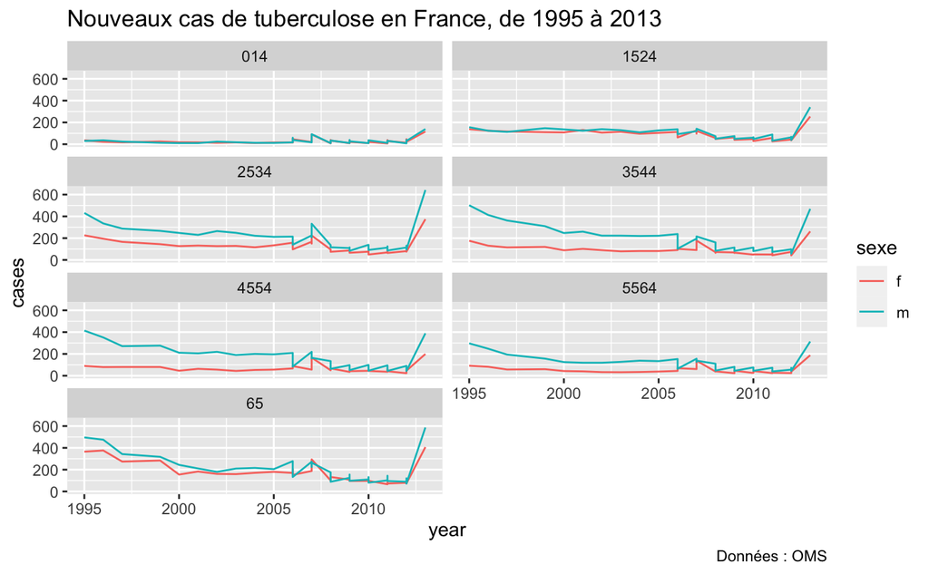

```r
tidyTB %>%
  filter(country == "France") %>%
  ggplot(aes(x = year, y = cases, color = sexe)) +
    geom_line() +
    facet_wrap(~age_class, ncol = 2) +
    labs(title = "Nouveaux cas de tuberculose en France, de 1995 à 2013",
         caption = "Données : OMS")
```

# Chapitre 6

Mise en mémoire des packages utiles

```r
library(dplyr)
library(ggplot2)
library(nycflights13)
```

## Exercice 6.4.2

*Dans la section 3.3.1, nous avons utilisé la fonction View et l’application manuelle de filtres pour déterminer combien de vols avaient quitté l’aéroport JFK le 12 février 2013. En utilisant la fonction filter(), créez un objet nommé `JFK_12fev` qui contiendra les données de ces vols. Vérifiez que cet objet contient bien 282 lignes.*

```r
JFK_12fev <- flights %>%
  filter(origin == "JFK",
         month == 2,
         day == 12)

JFK_12fev
```

| year | month | day | dep_time | sched_dep_time | dep_delay | arr_time | sched_arr_time | arr_delay | carrier | flight | tailnum | origin | dest | air_time | distance | hour | minute | time_hour |
| --- | --- | --- | --- | --- | --- | --- | --- | --- | --- | --- | --- | --- | --- | --- | --- | --- | --- | --- |
| 2013 | 2 | 12 | 17 | 2245 | 92 | 122 | 2356 | 86 | B6 | 128 | N627JB | JFK | BTV | 47 | 266 | 22 | 45 | 2013-02-12 22:00:00 |
| 2013 | 2 | 12 | 535 | 540 | -5 | 950 | 1016 | -26 | B6 | 725 | N659JB | JFK | BQN | 175 | 1576 | 5 | 40 | 2013-02-12 05:00:00 |
| 2013 | 2 | 12 | 539 | 540 | -1 | 828 | 850 | -22 | AA | 1141 | N625AA | JFK | MIA | 150 | 1089 | 5 | 40 | 2013-02-12 05:00:00 |
| 2013 | 2 | 12 | 555 | 600 | -5 | 903 | 911 | -8 | B6 | 135 | N638JB | JFK | RSW | 169 | 1074 | 6 | 0 | 2013-02-12 06:00:00 |
| 2013 | 2 | 12 | 555 | 600 | -5 | 858 | 925 | -27 | UA | 303 | N512UA | JFK | SFO | 342 | 2586 | 6 | 0 | 2013-02-12 06:00:00 |
| 2013 | 2 | 12 | 556 | 600 | -4 | 854 | 905 | -11 | B6 | 125 | N662JB | JFK | FLL | 152 | 1069 | 6 | 0 | 2013-02-12 06:00:00 |
| 2013 | 2 | 12 | 601 | 601 | 0 | 911 | 918 | -7 | UA | 1030 | N12125 | JFK | LAX | 334 | 2475 | 6 | 1 | 2013-02-12 06:00:00 |
| 2013 | 2 | 12 | 604 | 600 | 4 | 731 | 715 | 16 | EV | 5716 | N909EV | JFK | IAD | 53 | 228 | 6 | 0 | 2013-02-12 06:00:00 |
| 2013 | 2 | 12 | 608 | 610 | -2 | 905 | 901 | 4 | B6 | 145 | N566JB | JFK | PBI | 149 | 1028 | 6 | 10 | 2013-02-12 06:00:00 |
| 2013 | 2 | 12 | 610 | 615 | -5 | 859 | 855 | 4 | 9E | 3856 | N200PQ | JFK | ATL | 126 | 760 | 6 | 15 | 2013-02-12 06:00:00 |

[output cut: 272 more lines]

```r
nrow(JFK_12fev)
```

```
[1] 282
```

## Exercice 6.4.3

*Selon vous, quelles raisons peuvent expliquer qu’un vol qui a décollé n’ait pas d’heure d’atterrissage ?*

Le vol s’est écrasé ? Plus vraisemblablement, le vol a dû faire demi-tour ou être dérouté suite à un problème technique (ou météo ?).

## Exercice 6.5.6

*1. Faites un tableau indiquant combien de vols ont été annulés après le décollage, pour chaque compagnie aérienne.*

```r
flights %>%                     # On prend flights, puis
  filter(!is.na(dep_time),      # On filtre les vols ayant une heure de décollage
         is.na(arr_time)) %>%   # Mais pas d'heure d'arrivée, puis
  group_by(carrier) %>%         # On groupe par compagnie aérienne, puis
  summarize(cancelled = n())    # On compte le nombre de lignes par groupe
```

| carrier | cancelled |
| --- | --- |
| 9E | 71 |
| AA | 34 |
| B6 | 32 |
| DL | 15 |
| EV | 105 |
| F9 | 1 |
| FL | 6 |
| MQ | 87 |
| UA | 63 |
| US | 31 |

[output cut: 3 more lines]

*2. Faites un tableau indiquant les vitesses de vents minimales, maximales et moyennes, enregistrées chaque mois dans chaque aéroport de New York.*

```r
weather %>%
  group_by(origin, month) %>%
  summarize(max_wind = max(wind_speed, na.rm = TRUE),
            min_wind = min(wind_speed, na.rm = TRUE),
            moy_wind = mean(wind_speed, na.rm = TRUE))
```

| origin | month | max_wind | min_wind | moy_wind |
| --- | --- | --- | --- | --- |
| EWR | 1 | 42.57886 | 0 | 9.874685 |
| EWR | 2 | 1048.36058 | 0 | 12.202740 |
| EWR | 3 | 29.92028 | 0 | 11.613262 |
| EWR | 4 | 25.31716 | 0 | 9.628193 |
| EWR | 5 | 33.37262 | 0 | 8.488549 |
| EWR | 6 | 34.52340 | 0 | 9.551474 |
| EWR | 7 | 20.71404 | 0 | 9.148779 |
| EWR | 8 | 21.86482 | 0 | 7.623140 |
| EWR | 9 | 23.01560 | 0 | 8.029852 |
| EWR | 10 | 26.46794 | 0 | 8.324392 |

[output cut: 26 more lines]

*3. Sachant que les vitesses du vent sont exprimées en miles par heure, certaines valeurs sont-elles surprenantes ? À l’aide de la fonction `filter()`, éliminez la ou les valeurs aberrantes.*

Une valeur de plus de 1000 mph est impossible. Il s’agit vraisemblablement d’une erreur de saisie ou d’enregistrement.

```r
weather %>%
  filter(wind_speed <= 500) %>%
  group_by(origin, month) %>%
  summarise(max_wind = max(wind_speed, na.rm = TRUE),
            min_wind = min(wind_speed, na.rm = TRUE),
            moy_wind = mean(wind_speed, na.rm = TRUE))
```

| origin | month | max_wind | min_wind | moy_wind |
| --- | --- | --- | --- | --- |
| EWR | 1 | 42.57886 | 0 | 9.874685 |
| EWR | 2 | 31.07106 | 0 | 10.651606 |
| EWR | 3 | 29.92028 | 0 | 11.613262 |
| EWR | 4 | 25.31716 | 0 | 9.628193 |
| EWR | 5 | 33.37262 | 0 | 8.488549 |
| EWR | 6 | 34.52340 | 0 | 9.551474 |
| EWR | 7 | 20.71404 | 0 | 9.148779 |
| EWR | 8 | 21.86482 | 0 | 7.623140 |
| EWR | 9 | 23.01560 | 0 | 8.029852 |
| EWR | 10 | 26.46794 | 0 | 8.324392 |

[output cut: 26 more lines]

*4. En utilisant les données de vitesse de vent du tableau `weather`, produisez le graphique suivant.*

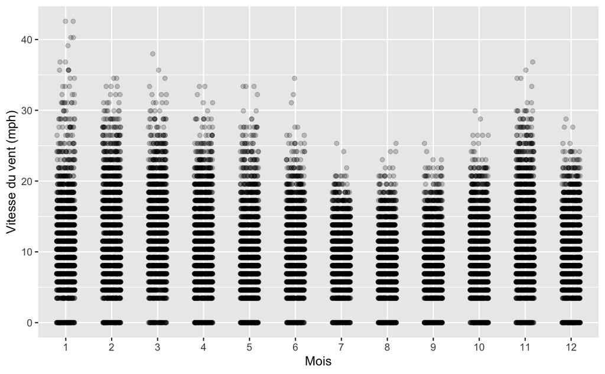

```r
weather %>%
  filter(wind_speed < 500) %>%
  ggplot(aes(x = factor(month), y = wind_speed)) +
  geom_jitter(width = 0.2, height = 0, alpha = 0.2) +
  labs(x = "Mois",
       y = "Vitesse du vent (mph)")
```

*Selon vous, pourquoi les points sont-ils organisés en bandes horizontales ?* *Selon vous, pourquoi n’y a t’il jamais de vent entre 0 et environ 3 miles à l’heure (mph) ?*

L’appareil de mesures n’enregistre que des vitesses de vent par incrément fixe et son seuil de détection est supérieur à des vitesses de 3mph. Cela explique les bandes et le trou entre 0 et 3 mph.

*Sachant qu’en divisant des mph par 1.151 on obtient des vitesses en nœuds, que nous apprend cette commande :*

```r
sort(unique(weather$wind_speed))/1.151
```

```
 [1]   0.000000   2.999427   3.999235   4.999044   5.998853   6.998662   7.998471   8.998280   9.998089  10.997897  11.997706  12.997515  13.997324  14.997133  15.996942  16.996751  17.996560  18.996368  19.996177  20.995986  21.995795  22.995604  23.995413  24.995222  25.995030  26.994839  27.99464…
```

Ici, on convertit les données de vitesse de vent de mph en nœuds. La fonction `unique()` permet d’éliminer les duplicats et `sort()` trie les données en ordre croissant. On voit donc que seules quelques valeurs de vent sont enregistrées. L’enregistreur est inacpable de détecter moins de 3 nœuds de vent, et ensuite, il enregistre des valeurs entières (3, 4, 5, et ainsi de suite jusqu’au maximum de 37 nœuds).

## Exercice 6.7.2

*1. Dans `ggplot2` le jeu de données `mpg` contient des informations sur 234 modèles de voitures. Examinez ce jeu de données avec la fonction `View()` et consultez l’aide de ce jeu de données pour savoir à quoi correspondent les différentes variables. Quelle(s) variable(s) nous renseignent sur la consommation des véhicules ? À quoi correspond la variable `disp` ?*

Les variables `hwy` et `cty` nous renseignent sur la consommation des véhicules sur autoroute et en ville respectivement. Les consommations sont données en miles per galon. `disp` est la cylindrée du moteur, son volume en litres.

*2. La consommation est donnée en miles par gallon. Créez une nouvelle variable `conso` qui contiendra la consommation exprimée en nombre de litres pour 100 kilomètres.*

```r
mpg %>%
  mutate(conso = 235.215 / hwy)
```

| manufacturer | model | displ | year | cyl | trans | drv | cty | hwy | fl | class | conso |
| --- | --- | --- | --- | --- | --- | --- | --- | --- | --- | --- | --- |
| audi | a4 | 1.8 | 1999 | 4 | auto(l5) | f | 18 | 29 | p | compact | 8.110862 |
| audi | a4 | 1.8 | 1999 | 4 | manual(m5) | f | 21 | 29 | p | compact | 8.110862 |
| audi | a4 | 2.0 | 2008 | 4 | manual(m6) | f | 20 | 31 | p | compact | 7.587581 |
| audi | a4 | 2.0 | 2008 | 4 | auto(av) | f | 21 | 30 | p | compact | 7.840500 |
| audi | a4 | 2.8 | 1999 | 6 | auto(l5) | f | 16 | 26 | p | compact | 9.046731 |
| audi | a4 | 2.8 | 1999 | 6 | manual(m5) | f | 18 | 26 | p | compact | 9.046731 |
| audi | a4 | 3.1 | 2008 | 6 | auto(av) | f | 18 | 27 | p | compact | 8.711667 |
| audi | a4 quattro | 1.8 | 1999 | 4 | manual(m5) | 4 | 18 | 26 | p | compact | 9.046731 |
| audi | a4 quattro | 1.8 | 1999 | 4 | auto(l5) | 4 | 16 | 25 | p | compact | 9.408600 |
| audi | a4 quattro | 2.0 | 2008 | 4 | manual(m6) | 4 | 20 | 28 | p | compact | 8.400536 |

[output cut: 224 more lines]

*3. Faîtes un graphique présentant la relation entre la cylindrée en litres et la consommation sur autoroute exprimée en nombre de litres pour 100 kilomètres. Vous excluerez les véhicules dont la `class`e est `2seater` de ce graphique (il s’agit de voitures de sports très compactes qu’il est difficile de mesurer aux autres). Sur votre graphique, la couleur devrait représenter le type de véhicule. Vous ajouterez une droite de régression en utilisant `geom_smooth(method = "lm")`.*

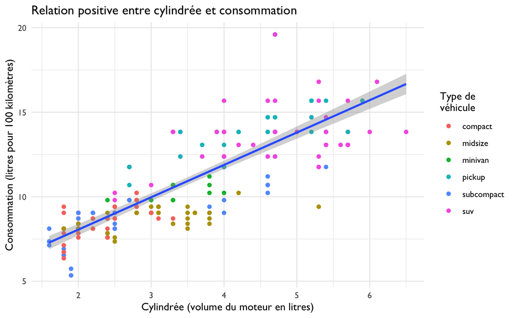

```r
mpg %>%
  filter(class != "2seater") %>%
  mutate(conso = 235.215 / hwy) %>%
  ggplot(aes(x = displ, y = conso)) +
  geom_point(aes(color = class)) +
  geom_smooth(method = "lm") +
  labs(x = "Cylindrée (volume du moteur en litres)",
       y = "Consommation (litres pour 100 kilomètres)",
       color = "Type de\nvéhicule",
       title = "Relation positive entre cylindrée et consommation") +
  theme_minimal(base_family = "Gill Sans")
```

*4. Ce graphique présente-t’il correctement l’ensemble des données de ces 2 variables ? Pourquoi ? Comparez le graphique de la question 3 ci-dessus et le graphique présenté ci-dessous. Selon vous, quels arguments et/ou fonctions ont été modifiés pour arriver à ce nouveau graphique ? Quels sont les avantages et les inconvénients de ce graphique par rapport au précédent ?

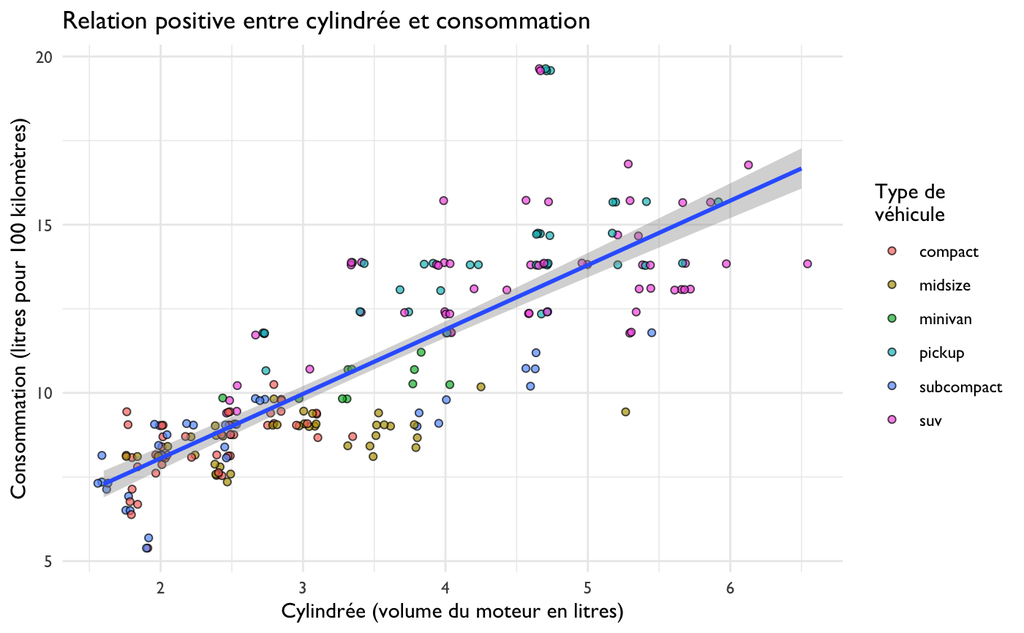

```r
mpg %>%
  filter(class != "2seater") %>%
  mutate(conso = 235.215 / hwy) %>%
  ggplot(aes(x = displ, y = conso)) +
  geom_jitter(aes(fill = class), shape = 21, width = 0.05, height = 0.05, alpha = 0.7) +
  geom_smooth(method = "lm") +
  labs(x = "Cylindrée (volume du moteur en litres)",
       y = "Consommation (litres pour 100 kilomètres)",
       fill = "Type de\nvéhicule",
       title = "Relation positive entre cylindrée et consommation") +
  theme_minimal(base_family = "Gill Sans")
```

On utilise `geom_jitter()` au lieu de `geom_point()` pour que les points ne se superposent plus. On voit donc mieux les données. Néanmoins, les points sont légèrement déplacés, ce graphique est donc moins précis que le premier. Il est plus inexact.

Les symboles ont aussi été changés : on est passé à des points avec contour (`shape = 21`) auquels on a attribué une transparence (toujours pour mieux visualiser les chevauchements de points). Du coup, ce n’est plus la `color` qui est associée à la classe de véhicule, mais `fill`, la couleur de remplissage.

## Exercice 6.10

*1. Créez un tableau `delayed` indiquant, pour chaque compagnie aérienne et chaque mois de l’année, le nombre de vols ayant eu un retard supérieur à 30 minutes à l’arrivée à destination. Ce tableau devrait contenir uniquement 3 colonnes :*

- `carrier` : la compagnie aérienne
- `month` : le mois de l’année 2013
- `n_delayed` : le nombre de vols ayant plus de 30 minutes de retard

```r
# Calcul du nombre de vols en retard (+ de 30 min à l'arrivée) pour chaque compagnie et chaque mois
delayed <- flights %>%
  filter(arr_delay > 30) %>%
  group_by(carrier, month) %>%
  summarize(n_delayed = n(), .groups = "drop")

delayed
```

| carrier | month | n_delayed |
| --- | --- | --- |
| 9E | 1 | 255 |
| 9E | 2 | 237 |
| 9E | 3 | 218 |
| 9E | 4 | 221 |
| 9E | 5 | 317 |
| 9E | 6 | 373 |
| 9E | 7 | 406 |
| 9E | 8 | 246 |
| 9E | 9 | 125 |
| 9E | 10 | 192 |

[output cut: 171 more lines]

*2. Créez un tableau `total` indiquant le nombre total de vols affrétés (et non annulés) par chaque compagnie aérienne et chaque mois de l’année. Ce tableau devrait contenir seulement 3 colonnes :*

- `carrier` : la compagnie aérienne
- `month` : le mois de l’année 2013
- `n_total` : le nombre total de vols arrivés à destination

```r
# Calcul du nombre total de vols non annulés pour chaque compagnie et chaque mois
total <- flights %>%
  filter(!is.na(arr_delay)) %>%
  group_by(carrier, month) %>%
  summarize(n_total = n())
total
```

| carrier | month | n_total |
| --- | --- | --- |
| 9E | 1 | 1480 |
| 9E | 2 | 1341 |
| 9E | 3 | 1510 |
| 9E | 4 | 1399 |
| 9E | 5 | 1383 |
| 9E | 6 | 1260 |
| 9E | 7 | 1339 |
| 9E | 8 | 1373 |
| 9E | 9 | 1468 |
| 9E | 10 | 1635 |

[output cut: 175 more lines]

*3. Fusionnez ces 2 tableaux en réalisant la jointure appropriée. Le tableau final, que vous nommerez `carrier_stats` devrait contenir 185 lignes. Si certaines colonnes contiennent des données manquantes, remplacez-les par des 0 à l’aide des fonctions `mutate()` et `na_replace()`.*

*4. Ajoutez à votre tableau `carrier_stats` une variable `rate` qui contient la proportion de vols arrivés à destination avec plus de 30 minutes de retard, pour chaque compagnie aérienne et chaque mois de l’année.*

*5. Ajoutez à votre tableau `carrier_stats` le nom complet des compagnies aériennes en réalisant la jointure appropriée avec le tableau `airlines`.*

```r
# Création du tableau de synthèse (2 left_join())
carrier_stats <- total %>%
  left_join(delayed) %>%
  mutate(n_delayed = replace_na(n_delayed, 0),
         rate = n_delayed / n_total) %>%
  left_join(airlines)
carrier_stats
```

| carrier | month | n_total | n_delayed | rate | name |
| --- | --- | --- | --- | --- | --- |
| 9E | 1 | 1480 | 255 | 0.17229730 | Endeavor Air Inc. |
| 9E | 2 | 1341 | 237 | 0.17673378 | Endeavor Air Inc. |
| 9E | 3 | 1510 | 218 | 0.14437086 | Endeavor Air Inc. |
| 9E | 4 | 1399 | 221 | 0.15796998 | Endeavor Air Inc. |
| 9E | 5 | 1383 | 317 | 0.22921186 | Endeavor Air Inc. |
| 9E | 6 | 1260 | 373 | 0.29603175 | Endeavor Air Inc. |
| 9E | 7 | 1339 | 406 | 0.30321135 | Endeavor Air Inc. |
| 9E | 8 | 1373 | 246 | 0.17916970 | Endeavor Air Inc. |
| 9E | 9 | 1468 | 125 | 0.08514986 | Endeavor Air Inc. |
| 9E | 10 | 1635 | 192 | 0.11743119 | Endeavor Air Inc. |

[output cut: 175 more lines]

*6. Faites un graphique synthétique présentant ces résultats de la façon la plus claire possible*

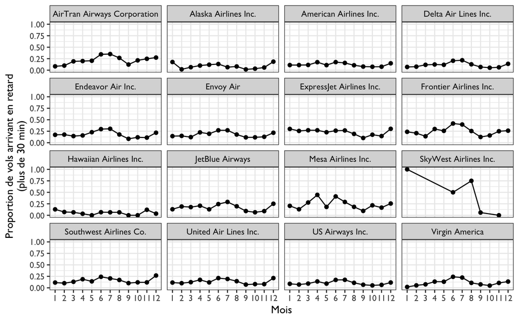

*7. Quelle compagnie aérienne semble se comporter très différemment des autres ? À quoi pouvez-vous attribuer ce comportement atypique ?*

La compagnie `OO` (SkyWest Airlines Inc.) a un comportement très atypique dû au très faible nombre de vols affrétés (1 seul en janvier, 2 en juin, 4 en août, 17 en septembre et 5 en novembre). Elle n’est d’ailleurs présente que quelques mois de l’année dans les aéroports de New York.

```r
carrier_stats %>%
  filter(carrier == "OO")
```

| carrier | month | n_total | n_delayed | rate | name |
| --- | --- | --- | --- | --- | --- |
| OO | 1 | 1 | 1 | 1.00000000 | SkyWest Airlines Inc. |
| OO | 6 | 2 | 1 | 0.50000000 | SkyWest Airlines Inc. |
| OO | 8 | 4 | 3 | 0.75000000 | SkyWest Airlines Inc. |
| OO | 9 | 17 | 1 | 0.05882353 | SkyWest Airlines Inc. |
| OO | 11 | 5 | 0 | 0.00000000 | SkyWest Airlines Inc. |

*8. Pour les compagnies affrétant un grand nombre de vols chaque année (e.g. `UA`, `B6` et `EV`), quelles sont les périodes où les plus fortes proportions de vols en retard sont observées ? Et les plus faibles ? Quelle(s) hypothèse(s) pouvez-vous formuler pour expliquer ces observations ?*

Pour les plus grosses compagnies, les retards les plus fréquents sont observés l’été, et les moins fréquents en automne. Cela correspond aux périodes de très fortes affluences en été, et au moins fortes affluences à la rentrée de septembre. C’est du moins le cas pour `UA` et `B6`. Moins pour `EV`.

```r
carrier_stats %>%
  filter(carrier %in% c("UA", "B6", "EV")) %>%
  select(carrier, month, n_total) %>%
  pivot_wider(names_from = carrier,
              values_from = n_total)
```

| month | B6 | EV | UA |
| --- | --- | --- | --- |
| 1 | 4413 | 3964 | 4590 |
| 2 | 3945 | 3539 | 4157 |
| 3 | 4746 | 4371 | 4909 |
| 4 | 4459 | 4321 | 4978 |
| 5 | 4537 | 4566 | 4890 |
| 6 | 4550 | 4075 | 4885 |
| 7 | 4902 | 4303 | 4971 |
| 8 | 4941 | 4337 | 5085 |
| 9 | 4270 | 4548 | 4636 |
| 10 | 4357 | 4812 | 5035 |

[output cut: 2 more lines]

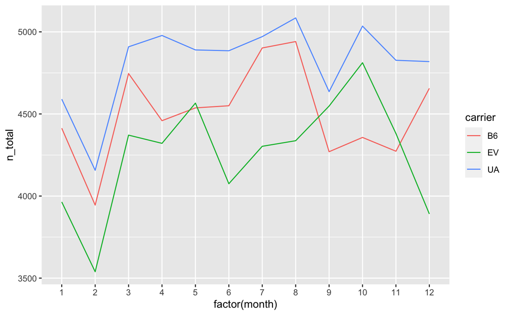

```r
carrier_stats %>%
  filter(carrier %in% c("UA", "B6", "EV")) %>%
  ggplot(aes(x = factor(month), y = n_total, group = carrier, color = carrier)) +
    geom_line()
```

*9. Faites un tableau synthétique présentant ces résultats de la façon la plus compacte et claire que possible, afin par exemple de les intégrer à un rapport.*

| carrier | month | n_total | n_delayed | rate | name |
| --- | --- | --- | --- | --- | --- |
| 9E | 1 | 1480 | 255 | 0.17229730 | Endeavor Air Inc. |
| 9E | 2 | 1341 | 237 | 0.17673378 | Endeavor Air Inc. |
| 9E | 3 | 1510 | 218 | 0.14437086 | Endeavor Air Inc. |
| 9E | 4 | 1399 | 221 | 0.15796998 | Endeavor Air Inc. |
| 9E | 5 | 1383 | 317 | 0.22921186 | Endeavor Air Inc. |
| 9E | 6 | 1260 | 373 | 0.29603175 | Endeavor Air Inc. |
| 9E | 7 | 1339 | 406 | 0.30321135 | Endeavor Air Inc. |
| 9E | 8 | 1373 | 246 | 0.17916970 | Endeavor Air Inc. |
| 9E | 9 | 1468 | 125 | 0.08514986 | Endeavor Air Inc. |
| 9E | 10 | 1635 | 192 | 0.11743119 | Endeavor Air Inc. |

[output cut: 175 more lines]